# Hydration Behaviour

# An Observational Visual Story

[interactive chart not shown]

Lo-fi ambient music with gentle rain sounds - DesiFreeMusic - pixabay.com

## Understanding the Dataset: Hydration Behaviour Overview

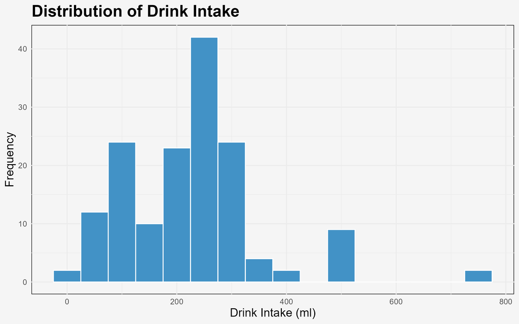

Histogram showing the distribution of drink intake amounts recorded across all observations.

The dataset combines both older group survey data (March/April) and newer personal observational data. Each row represents a single drinking event rather than a daily total.

Most recorded drinks fall within a moderate intake range, with a few large values. The newer data focuses more havily on personal routine and environmental observations.

During the making of this, 154 observations were recorded. Additionally the study shifted from group-based responses to a longitudinal self-observation.

## Hydration Behaviour Patterns

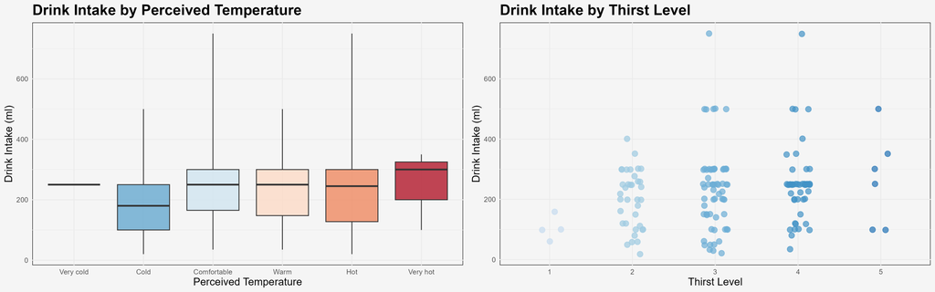

Boxplot comparing drink intake across different perceived temperature categories & Jitter plot showing drink intake values across different thirst levels.

Drink intake appears to vary slightly depending on perceived environmental warmth. Cold and comfortable conditions showed moderate intake values.

[interactive chart not shown]

Atmosphere of Atlantis - SamuelFJohanns - pixabay.com

## Perceptions vs Reality: Environmental Conditions

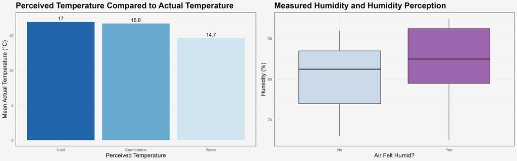

Two plots comparing perceived environmental conditions against measured temperature and humidity values.

Perceived temperature did not always align with measured temperature values. “Cold” conditions show a higher mean temperature than expected.

Measured humidity was generally higher when the environment felt humid.

Indoor conditions and heater use likely influenced environmental perception. These results highlight the difference between objective measurements and subjective experience.

The old data only collected the perceived temperature and humidity while the new data added measured outdoor temperature and humidity according to a Weather app. The new data collection started after the seasonal changes became apparent.

As the perceived temperature will be the room temperature for most respondents, it makes sense that a “Warm” indoor temperature will result in a lower mean when it’s “Cold” outside. Additionally, heater use reduces the humidity inside the room.

## Daily Hydration and Routine Behaviour

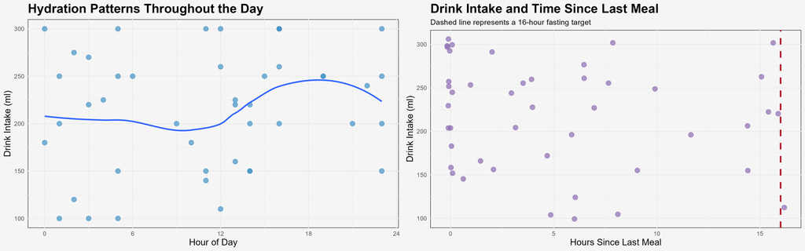

Combined visualisation showing hydration behaviour across time of day and time since last meal

Hydration patters varied considerably across different times of day. Morning observations were limited due to personal sleep schedule.

Clusters around long meal gaps suggest intermittent fasting behaviour. Many drinking events occurred immediately after meals. The dashed fasting line highlights the approximate fasting target used during the study period.

The new data was collected over a week and accounts for around 30% of the overall data. The newer dataset reflects personal lifestyle habits such as sleep schedule, meal timing and indoor routines, which likely influenced both hydration behaviour and environmental perception.

Becasue the data was collected repeatedly over time from a single respondent, longer-term behavioural patters became easier to observe compared to the earlier group-based survey data.

## Key Observations and Reflections

Hydration behaviour appeared to be influenced by both environmental and behavioural factors. Subjective perception was sometimes more informative than measured environmental conditions as the measured data did not reflect the room temperature adequately.

Personal routine had a strong effect on hydration timing and intake. Some relationships appeared weak or inconsistent, highlighting the complexity of behavioural data.